# Part 1 - Introduction to base R

2023-08-14

## Exercises for data manipulation with base R

[Go back to homepage](https://rcourseatkb.github.io/KB-R-course/frontpage.html)

### Exercise 1 - Descriptive statistics

We will be working on data from a randomised trial of two treatment regimens for lung cancer, the Veteran’s Administration Lunc Cancer study. The data are provided as part of the `survival`-package and can be loaded by first installing the package (NB if you have already installed the package, you don’t have to do it again):

```r
install.packages("survival")
```

Load the data into an R-data set with the name `vet` using:

```r
vet <- survival::veteran
```

The data set `vet` contains the following variables:

- `trt`: 1=standard 2=test
- `celltype`: 1=squamous, 2=smallcell, 3=adeno, 4=large
- `time`: survival time
- `status`: censoring status, 1=dead, 0=censored
- `karno`: Karnofsky performance score (100=good)
- `diagtime`: months from diagnosis to randomisation
- `age`: in years
- `prior`: prior therapy 0=no, 10=yes

Data manipulations and simple descriptive statistics

##### 1. How many veterans are included in the study? How many veterans are randomized to each treatment arm?

**Show the solution for 1**

```r
dim(vet)
```

```
## [1] 137   8
```

```r
table(vet$trt)
```

```
##
##  1  2
## 69 68
```

##### 2. What are the types of the variables?

**Show the solution for 2**

```r
str(vet)
```

```
## 'data.frame':    137 obs. of  8 variables:
##  $ trt     : num  1 1 1 1 1 1 1 1 1 1 ...
##  $ celltype: Factor w/ 4 levels "squamous","smallcell",..: 1 1 1 1 1 1 1 1 1 1 ...
##  $ time    : num  72 411 228 126 118 10 82 110 314 100 ...
##  $ status  : num  1 1 1 1 1 1 1 1 1 0 ...
##  $ karno   : num  60 70 60 60 70 20 40 80 50 70 ...
##  $ diagtime: num  7 5 3 9 11 5 10 29 18 6 ...
##  $ age     : num  69 64 38 63 65 49 69 68 43 70 ...
##  $ prior   : num  0 10 0 10 10 0 10 0 0 0 ...
```

```r
head(vet)
```

```
##   trt celltype time status karno diagtime age prior
## 1   1 squamous   72      1    60        7  69     0
## 2   1 squamous  411      1    70        5  64    10
## 3   1 squamous  228      1    60        3  38     0
## 4   1 squamous  126      1    60        9  63    10
## 5   1 squamous  118      1    70       11  65    10
## 6   1 squamous   10      1    20        5  49     0
```

##### 3. Use the `summary()` function on the veteran data frame. How and why do the output differ for the variables `age` and `celltype`?

**Show the solution for 3**

```r
summary(vet)
```

```
##       trt             celltype       time           status
##  Min.   :1.000   squamous :35   Min.   :  1.0   Min.   :0.0000
##  1st Qu.:1.000   smallcell:48   1st Qu.: 25.0   1st Qu.:1.0000
##  Median :1.000   adeno    :27   Median : 80.0   Median :1.0000
##  Mean   :1.496   large    :27   Mean   :121.6   Mean   :0.9343
##  3rd Qu.:2.000                  3rd Qu.:144.0   3rd Qu.:1.0000
##  Max.   :2.000                  Max.   :999.0   Max.   :1.0000
##      karno          diagtime           age            prior
##  Min.   :10.00   Min.   : 1.000   Min.   :34.00   Min.   : 0.00
##  1st Qu.:40.00   1st Qu.: 3.000   1st Qu.:51.00   1st Qu.: 0.00
##  Median :60.00   Median : 5.000   Median :62.00   Median : 0.00
##  Mean   :58.57   Mean   : 8.774   Mean   :58.31   Mean   : 2.92
##  3rd Qu.:75.00   3rd Qu.:11.000   3rd Qu.:66.00   3rd Qu.:10.00
##  Max.   :99.00   Max.   :87.000   Max.   :81.00   Max.   :10.00
```

##### 4. Define an ID-variable in the `vet` data by adding a variable with values 1 to $n$, $n$ being the number of veterans in the study. Hint: You can define a sequence with numbers from 1 to 10 using `1:10`.

**Show the solution for 4**

```r
vet$id <- 1:137
```

##### 5. Delete the variable `time` from your `vet` data.

**Show the solution for 5**

```r
vet <- subset(vet, select = -c(time))
# Alternatively:
# vet$time <- NULL
```

##### 6. Define a dummy(0/1)-variable named `karno50` in the data set indicating whether the Karnofsky score is above($\geq$) or below(<) 50 points. Hint: You may use the `ifelse()`-function (see e.g. Chapter 5.4.3 of the online introduction to R).

**Show the solution for 6**

```r
vet$karno50 <- ifelse(vet$karno >= 50, 1, 0)
```

##### 7. How many of the veterans with a Karnofsky score below, respectively above, 50 points died (`status==1`)? Find out in two ways:

1. By defining subsets of the data containing only the dead veterans with a Karnofsky score above, respectively below, 50 points. Count the number of veterans in each sub data set.

**Show the solution for 7.1**

```r
vet1 <- subset(vet, status==1 & karno50==1)
dim(vet1)
```

```
## [1] 91  9
```

```r
vet2 <- subset(vet, status==1 & karno50==0)
dim(vet2)
```

```
## [1] 37  9
```

2. By making a two-way table of `status` vs `karno50`.

**Show the solution for 7.2**

```r
tab <- table(vet$karno50, vet$status, dnn = c("Karno > 50", "Status"))
```

##### 8. Determine the proportion of dead veterans for those with a Karnofsky score below, respectively above, 50 points.

**Show the solution for 8**

```r
prop.table(tab, margin = 1)
```

```
##           Status
## Karno > 50          0          1
##          0 0.02631579 0.97368421
##          1 0.08080808 0.91919192
```

##### 9. Determine the following summary measures for the Karnofsky score:

- the mean
- the variance
- the median
- the quartiles

**Show the solution for 9**

```r
mean(vet$karno)
```

```
## [1] 58.56934
```

```r
var(vet$karno)
```

```
## [1] 401.5852
```

```r
sd(vet$karno) # standard deviation
```

```
## [1] 20.03959
```

```r
quantile(vet$karno) # both for quartiles and median
```

```
##   0%  25%  50%  75% 100%
##   10   40   60   75   99
```

```r
# Alternatevely
# summary(vet$karno)
```

##### 10. Determine the mean Karnofsky score for each cell type separately. Does the level of the Karnofsky score seem to differ between cell type groups, and how would you illustrate the data?

**Show the solution for 10**

```r
tapply(vet$karno, vet$celltype, mean)
```

```
##  squamous smallcell     adeno     large
##  60.85714  53.54167  58.11111  65.00000
```

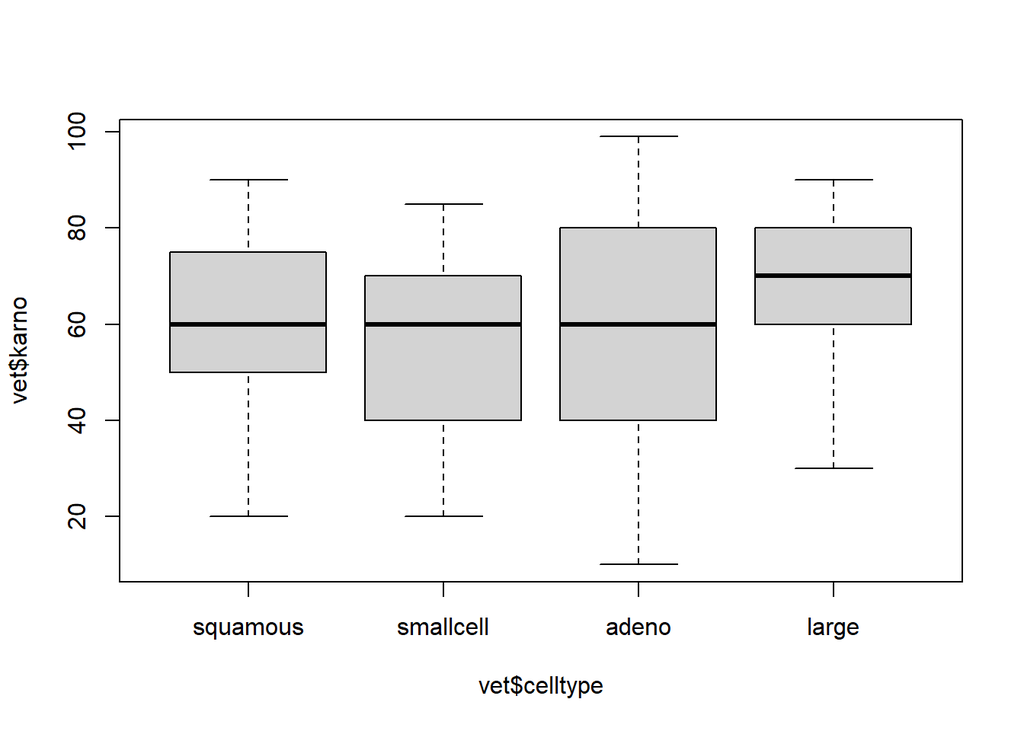

```r
boxplot(vet$karno ~ vet$celltype)
```

##### 11. Define a grouped version of the `age`-variable grouping age into “<= 50”, “50-65”, “> 65”. Hint: use the `cut()`-function. How many veterans do you find in each group?

**Show the solution for 11**

```r
range(vet$age)
```

```
## [1] 34 81
```

```r
vet$ageGroup <- cut(vet$age, c(30,50,65,100), labels = c("<= 50","50-65","> 65"))
table(vet$ageGroup)
```

```
##
## <= 50 50-65  > 65
##    34    66    37
```

##### 12. Make a Table 1 including the variables `celltype`, `karno`, `diagtime`, `age`, `prior` stratified on treatment `trt`. Make sure that all variables are tabulated in the correct way. Does it make sense to report mean and SD for all the quantitative variables or should we rather use median and IQR (Inter Quartile Range) (if so, use the help function to find out how) (hint: `print(object, showAllLevels=T, nonnormal = c('age','diagtime'))`)?

**Show the solution for 12**

```r
library(tableone)
vet1 <- subset(vet, select = c(celltype, karno, diagtime, age, prior, trt))
tab1 <- CreateTableOne(data = vet1, strata = 'trt', test = FALSE,
                       vars = c('celltype', 'karno', 'diagtime', 'age', 'prior'),
                       factorVars = c('prior'))
print(tab1, showAllLevels = T, nonnormal = c('age','diagtime'))
```

```
##                          Stratified by trt
##                           level     1                    2
##   n                                    69                   68
##   celltype (%)            squamous     15 (21.7)            20 (29.4)
##                           smallcell    30 (43.5)            18 (26.5)
##                           adeno         9 (13.0)            18 (26.5)
##                           large        15 (21.7)            12 (17.6)
##   karno (mean (SD))                 59.20 (18.74)        57.93 (21.40)
##   diagtime (median [IQR])            5.00 [4.00, 11.00]   4.50 [3.00, 11.00]
##   age (median [IQR])                62.00 [49.00, 66.00] 62.00 [52.00, 66.00]
##   prior (%)               0            48 (69.6)            49 (72.1)
##                           10           21 (30.4)            19 (27.9)
```

### Exercise 2 - Visualizing data

**Show the solution for 1**

```r
library(MASS)
head(crabs)
```

```
##   sp sex index   FL  RW   CL   CW  BD
## 1  B   M     1  8.1 6.7 16.1 19.0 7.0
## 2  B   M     2  8.8 7.7 18.1 20.8 7.4
## 3  B   M     3  9.2 7.8 19.0 22.4 7.7
## 4  B   M     4  9.6 7.9 20.1 23.1 8.2
## 5  B   M     5  9.8 8.0 20.3 23.0 8.2
## 6  B   M     6 10.8 9.0 23.0 26.5 9.8
```

##### 2. Look at the help page to learn about the variables in the data

**Show the solution for 2**

```r
?crabs
```

```
## starting httpd help server ... done
```

##### 3. Get an initial feeling of the data by plotting all pair of variables

**Show the solution for 3**

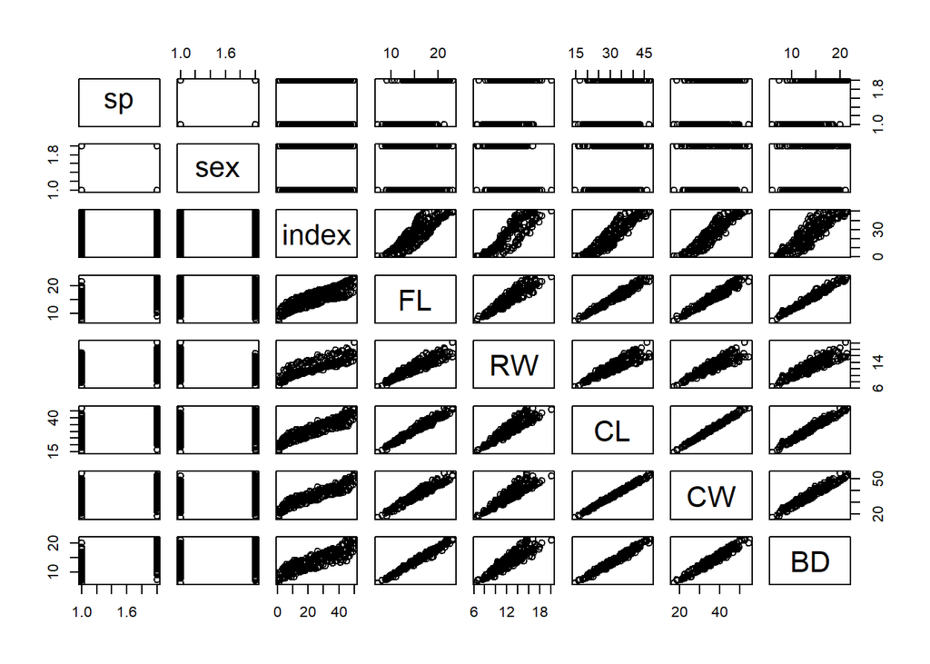

```r
pairs(crabs)
```

##### 4. Make a box plot outlining the (rear width) distributions among sexes.

**Show the solution for 4**

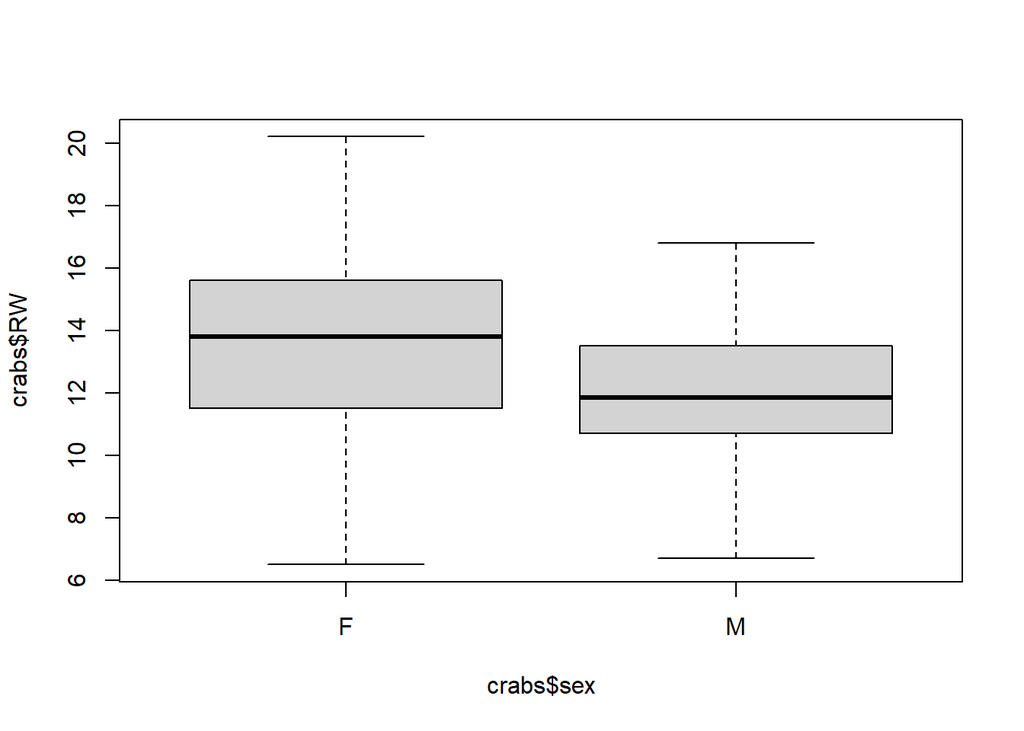

```r
boxplot(crabs$RW ~ crabs$sex)
```

##### 5. Make a histogram for the variable (carapace length) and (frontal lobe size)

**Show the solution for 5**

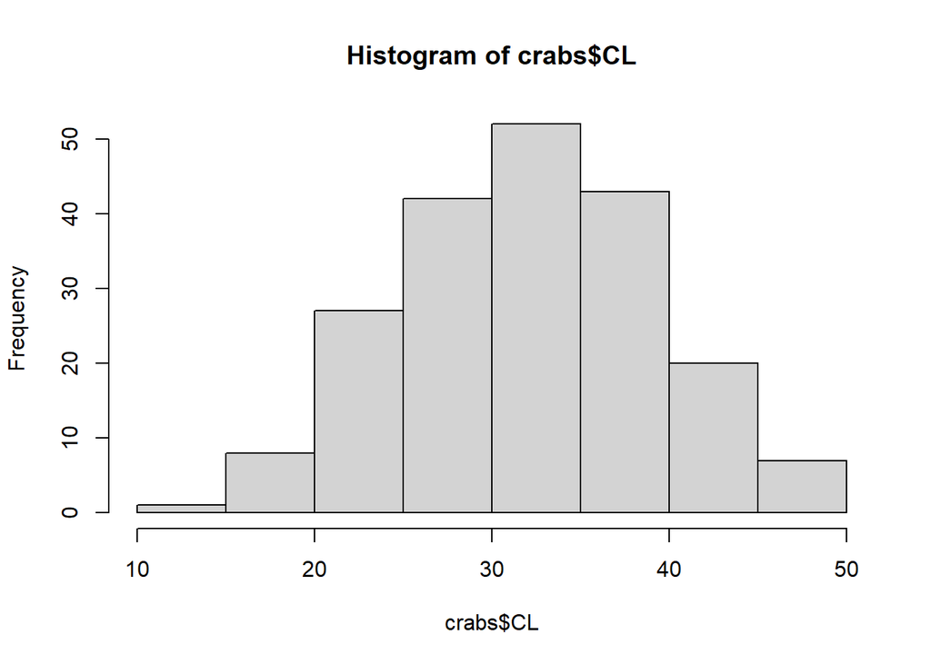

```r
hist(crabs$CL)
```

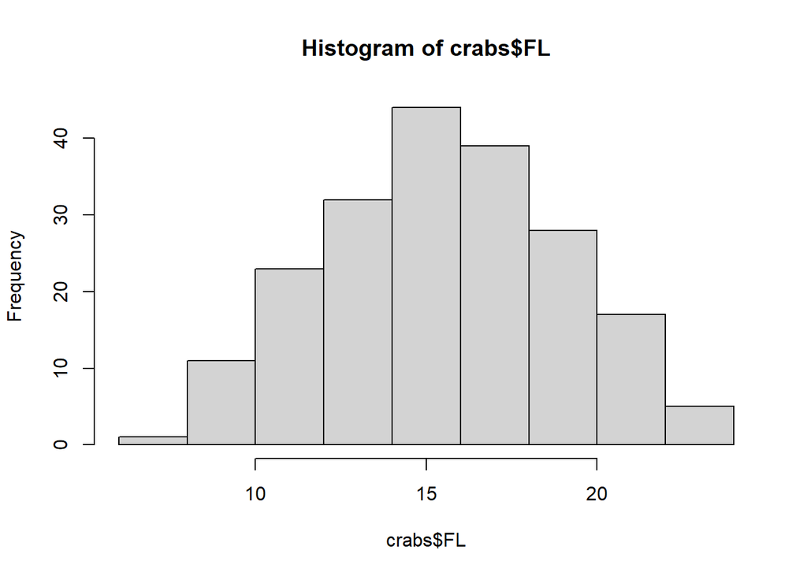

```r
hist(crabs$FL)
```

##### 6. Create a scatterplot showing the relationship between frontal lobe size and rear width

**Show the solution for 6**

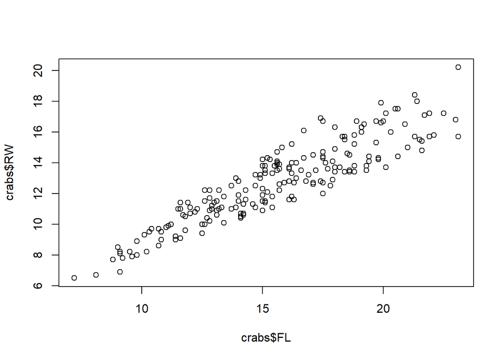

```r
plot(crabs$FL, crabs$RW)
```

##### 7. Change the plot character of the points to filled squares

**Show the solution for 7**

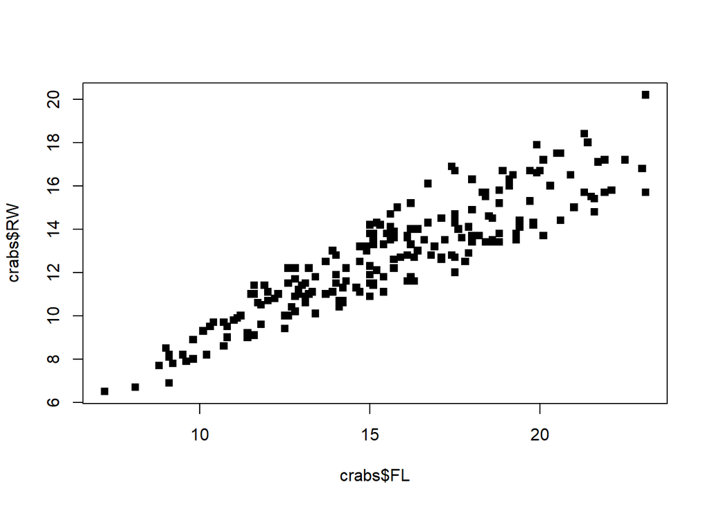

```r
plot(crabs$FL, crabs$RW, pch = 15)
```

##### 8. Increase the size of the points

**Show the solution for 8**

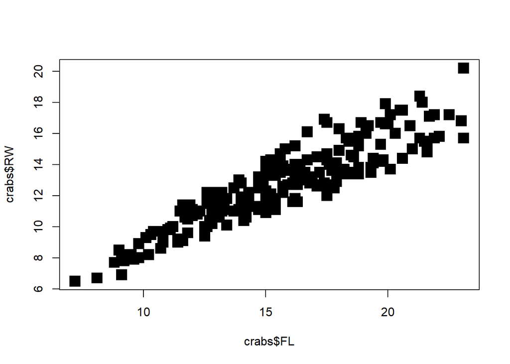

```r
plot(crabs$FL, crabs$RW, pch = 15, cex = 2)
```

##### 9. Save the plot as a PNG file. Go to the folder where you saved the file and open it

**Show the solution for 9**

```r
png("myfile.png")
plot(crabs$FL, crabs$RW, pch = 15, cex = 2)
dev.off()
```

##### 10. Create another scatterplot of carapace width versus rear width. Change the default axis labels to make them understandable to the reader (e.g.~spell out the variable names abbreviated in the data)

**Show the solution for 10**

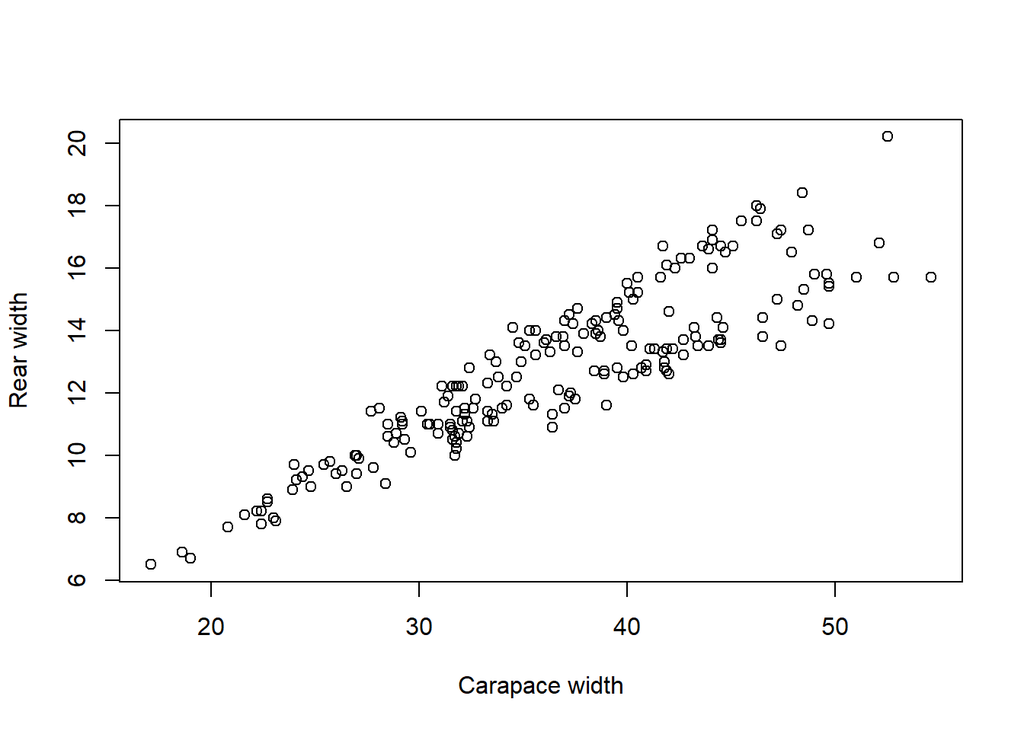

```r
plot(crabs$CW, crabs$RW, xlab = "Carapace width", ylab = "Rear width")
```

##### 11. Use separate plot characters for each sex (hint: change to a numeric variable)

**Show the solution for 11**

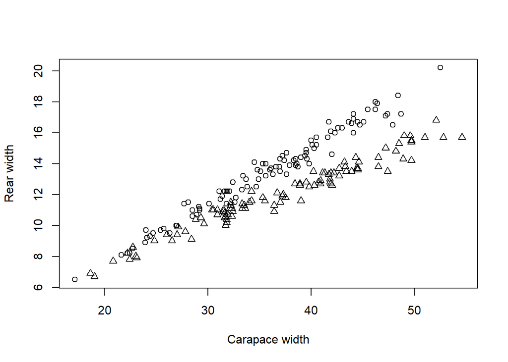

```r
plot(crabs$CW, crabs$RW, xlab = "Carapace width", ylab = "Rear width",
     pch = as.numeric(crabs$sex))
```

##### 12. Color the data points according to the species type

**Show the solution for 12**

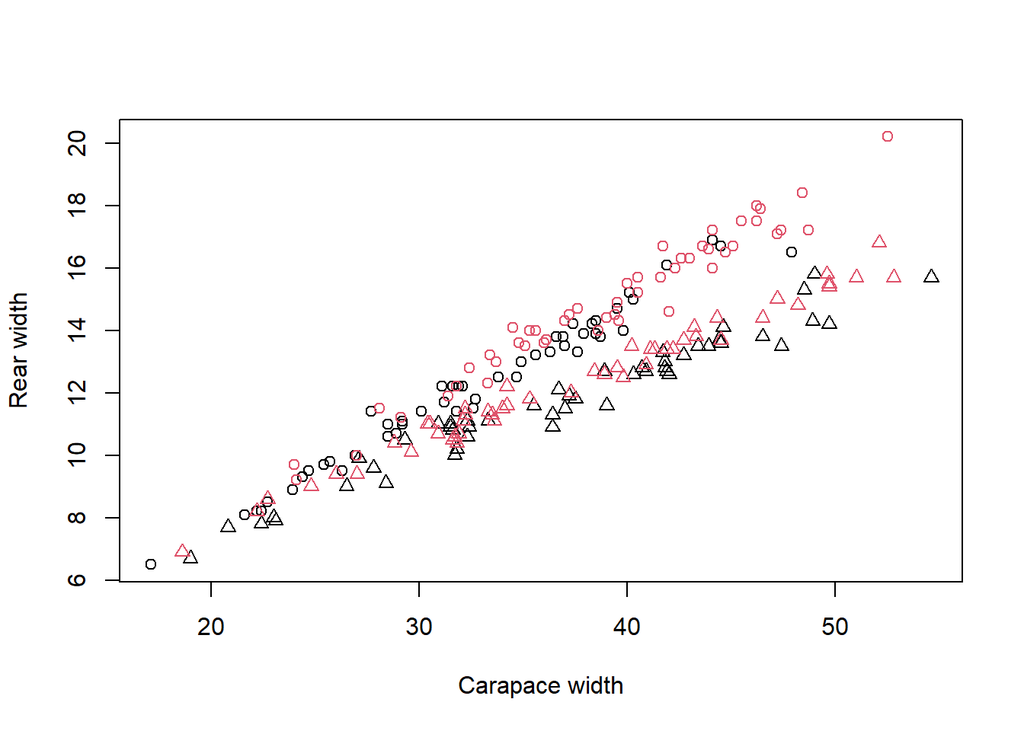

```r
plot(crabs$CW, crabs$RW, xlab = "Carapace width", ylab = "Rear width",
     pch = as.numeric(crabs$sex), col = crabs$sp)
```

##### 13. Add a legend to the plot to illustrate how sex and species type are specified in the plot.

**Show the solution for 13**

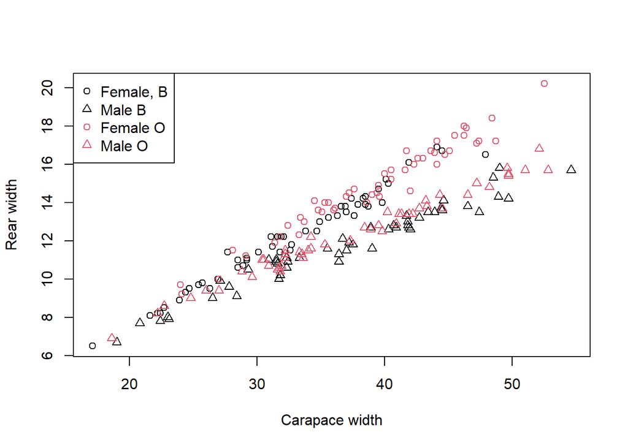

```r
plot(crabs$CW, crabs$RW, xlab = "Carapace width", ylab = "Rear width",
     pch = as.numeric(crabs$sex), col = crabs$sp)
legend('topleft',c('Female, B','Male B','Female O','Male O'),
       pch = c(1, 2, 1, 2), col = c(1, 1, 2, 2))
```

##### 14. Add a title to the plot

**Show the solution for 14**

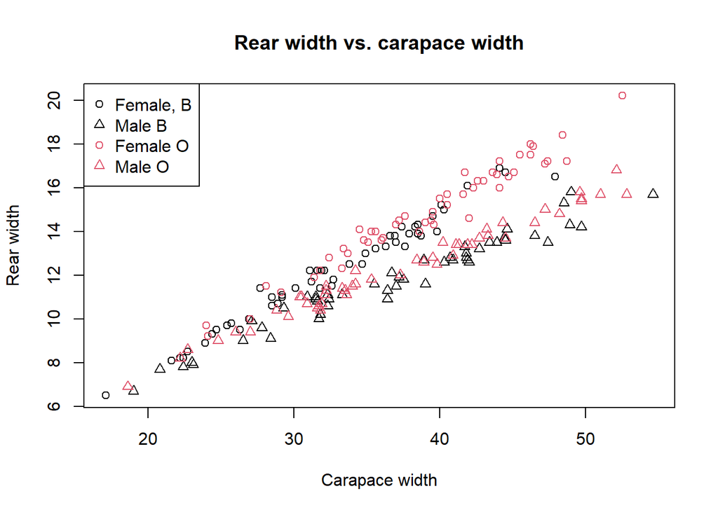

```r
plot(crabs$CW, crabs$RW, xlab = "Carapace width", ylab = "Rear width",
     pch = as.numeric(crabs$sex), col = crabs$sp,
     main = 'Rear width vs. carapace width')
legend('topleft', c('Female, B','Male B','Female O','Male O'),
       pch = c(1, 2, 1, 2), col = c(1, 1, 2, 2))
```

##### 15. What information can be derived from the plot? Do you see any patterns?

**Show the solution for 15**

```r
"In the plot we can see that there is a linear relationship between the variables carapace width and rear width. We can also see that the rear width of the males is lower than the one of the females for carapace width greater than 30 and this difference becomes bigger for increasing values of carapace width. From the plot we cannot identify any difference among the species for rear width and carapace width."
```

[output not shown]

##### 16. Draw the two scatterplots from question 6 and 10 again in a single figure. Place one plot above the other

**Show the solution for 16**

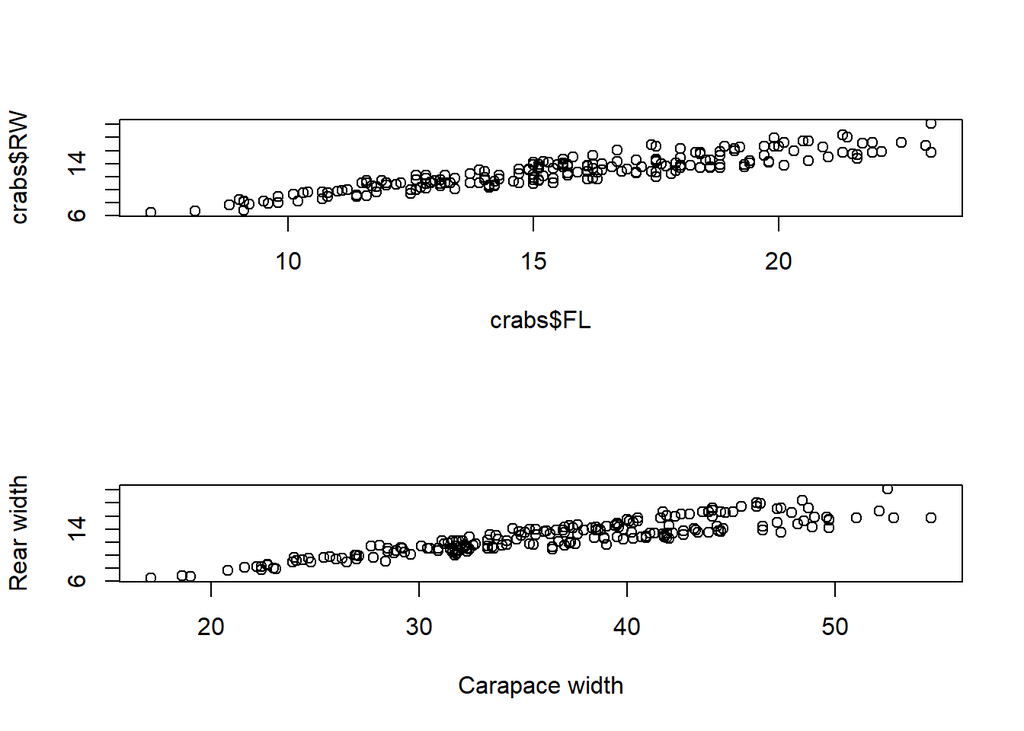

```r
par(mfrow=c(2,1))
plot(crabs$FL, crabs$RW)
plot(crabs$CW, crabs$RW, xlab = "Carapace width", ylab = "Rear width")
```

##### 17. Save the combined figure as a PDF file with width 5 and height 10. Open the file and compare it to the PNG file you saved in question 9

**Show the solution for 17**

```r
pdf("myfile.pdf", width = 5, height = 10)
par(mfrow = c(2, 1))
plot(crabs$FL, crabs$RW)
plot(crabs$CW, crabs$RW, xlab = "Carapace width", ylab = "Rear width")
dev.off()
```

### Exercise 3 - Visualizing data (extra)

##### 1. Clear the workspace

**Show the solution for 1**

```r
rm(list = ls())
```

**Show the solution for 2**

```r
x <- c(1:10)
y <- c(1:10)
```

**Show the solution for 3**

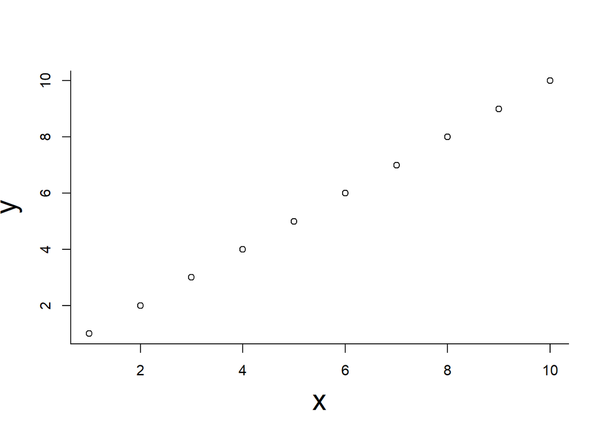

```r
plot(x, y, cex.lab = 2, bty = 'l')
```

##### 4. Make the $y$-axis label horizontal

**Show the solution for 4**

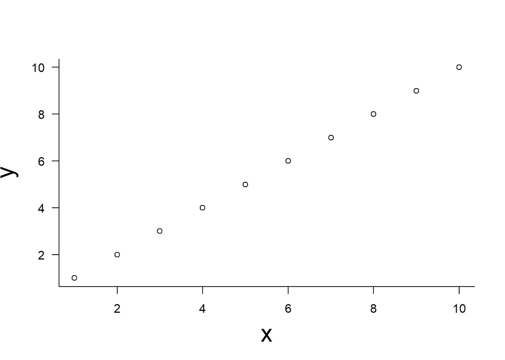

```r
plot(x, y, cex.lab = 2, bty = 'l', las = 1)
```

##### 5. Add a straight red line that goes through all the points

**Show the solution for 5**

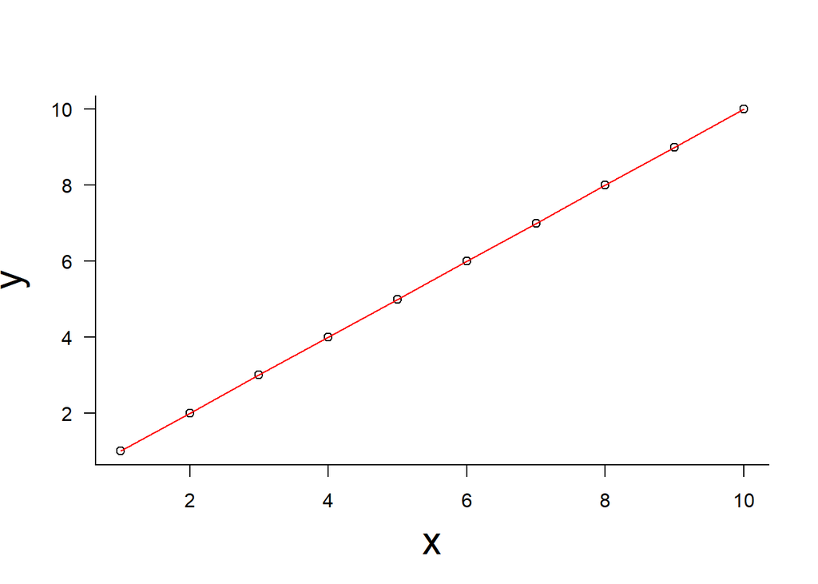

```r
plot(x, y, cex.lab = 2, bty = 'l', las = 1)
lines(x, y, col = 'red')
```

##### 6. Add a horizontal blue line in y=5

**Show the solution for 6**

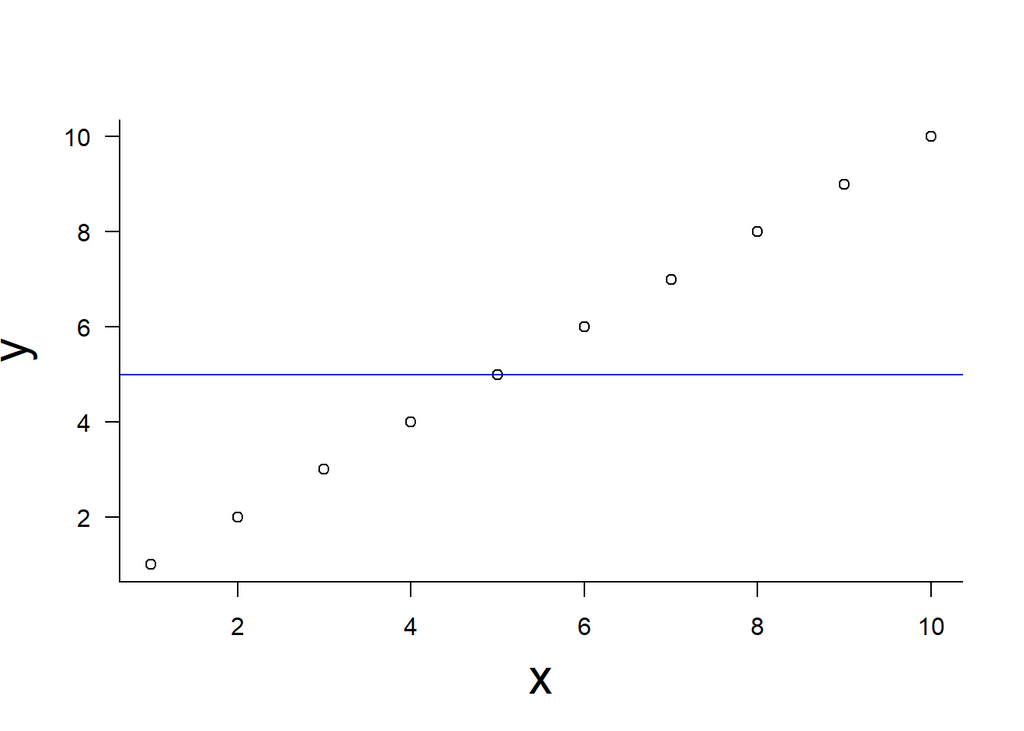

```r
plot(x, y, cex.lab = 2, bty = 'l', las = 1)
abline(h = 5, col = 'blue')
```

### Bonus exercises

Sorting data (OPTIONAL)

Reload the veteran study data:

**Show the solution for 1**

```r
vet <- survival::veteran
```

##### 1. Order the data `vet` by increasing value of the `time`-variable.

**Show the solution for 1**

```r
vet <- vet[order(vet$time), ]
```

##### 2. Order the data by decreasing value of `status` variable (i.e. the dead first) and increasing value of `time`.

**Show the solution for 2**

```r
vet <- vet[order(-vet$status, vet$time), ]
```

##### 3. Suppose we want to add data on one more veteran to our `vet` data set. The veteran has values

```r
new <- data.frame(trt = 1,
                  celltype = "large",
                  time = 204,
                  status = 0,
                  karno = 88,
                  age = 55)
```

Add the values for this extra veteran to the `vet` data using `rbind()`. R will give you an error message - what is the problem and how can you correct the error?

**Show the solution for 3**

```r
new$id <- 138
new$karno50 <- ifelse(new$karno >= 50, 1, 0)
```